# An analysis of user behavior in a mobile application

Analyze the sales funnel and the results of an A/A/B test. We need to understand how food startup users behave a mobile application. We agreed to make a decision based on the results of an A/A/B test after the designers wanted to change fonts throughout the application. To determine which font is the most effective, users were divided into three groups: two control groups with old fonts, and one experimental group with new fonts. Two control groups have certain advantages. If the two control groups are equal, the test can be assumed to be accurate. In the case where the two control groups differ significantly, the causes of the distortion can be identified.

## Data overview

```python
# importing libraries
import pandas as pd
import matplotlib.pyplot as plt
import seaborn as sns
import math as mth
import plotly.graph_objects as go
import numpy as np

from scipy import stats as st
from plotly.subplots import make_subplots
from pandas.plotting import register_matplotlib_converters
```

```python
# changing the display settings
pd.set_option('display.max_columns', None)
pd.options.display.max_colwidth = 100
pd.options.display.float_format = '{:,.2f}'.format
register_matplotlib_converters()
```

```python
# reading csv files and assigning the result to variables
logs = pd.read_csv('https://code.s3.yandex.net/datasets/logs_exp.csv', sep = '\t')
```

```python
# displaying the head of the DataFrame
logs.head(10)
```

|  | EventName | DeviceIDHash | EventTimestamp | ExpId |
| --- | --- | --- | --- | --- |
| 0 | MainScreenAppear | 4575588528974610257 | 1564029816 | 246 |
| 1 | MainScreenAppear | 7416695313311560658 | 1564053102 | 246 |
| 2 | PaymentScreenSuccessful | 3518123091307005509 | 1564054127 | 248 |
| 3 | CartScreenAppear | 3518123091307005509 | 1564054127 | 248 |
| 4 | PaymentScreenSuccessful | 6217807653094995999 | 1564055322 | 248 |
| 5 | CartScreenAppear | 6217807653094995999 | 1564055323 | 248 |
| 6 | OffersScreenAppear | 8351860793733343758 | 1564066242 | 246 |
| 7 | MainScreenAppear | 5682100281902512875 | 1564085677 | 246 |
| 8 | MainScreenAppear | 1850981295691852772 | 1564086702 | 247 |
| 9 | MainScreenAppear | 5407636962369102641 | 1564112112 | 246 |

- Change column names to snake case and lowercase;
- Add a date and time column, as well as a separate date column.

```python
# printing information about the DataFrame
logs.info()

# computing a summary of statistics
logs.describe()
```

```
<class 'pandas.core.frame.DataFrame'>
RangeIndex: 244126 entries, 0 to 244125
Data columns (total 4 columns):
EventName         244126 non-null object
DeviceIDHash      244126 non-null int64
EventTimestamp    244126 non-null int64
ExpId             244126 non-null int64
dtypes: int64(3), object(1)
memory usage: 7.5+ MB
```

|  | DeviceIDHash | EventTimestamp | ExpId |
| --- | --- | --- | --- |
| count | 244,126.00 | 244,126.00 | 244,126.00 |
| mean | 4,627,568,124,590,853,120.00 | 1,564,913,915.84 | 247.02 |
| std | 2,642,424,998,963,707,904.00 | 177,134.32 | 0.82 |
| min | 6,888,746,892,508,752.00 | 1,564,029,816.00 | 246.00 |
| 25% | 2,372,212,476,992,240,640.00 | 1,564,756,580.25 | 246.00 |
| 50% | 4,623,191,541,214,045,184.00 | 1,564,919,395.00 | 247.00 |
| 75% | 6,932,517,045,703,054,336.00 | 1,565,074,511.00 | 248.00 |
| max | 9,222,603,179,720,523,776.00 | 1,565,212,517.00 | 248.00 |

- There are no gaps in the data;
- Data types are correct.

```python
# checking for values in all columns
logs['EventName'].value_counts()
```

```
MainScreenAppear           119205
OffersScreenAppear          46825
CartScreenAppear            42731
PaymentScreenSuccessful     34313
Tutorial                     1052
Name: EventName, dtype: int64
```

```python
# checking for values in all columns
logs['ExpId'].value_counts()
```

```
248    85747
246    80304
247    78075
Name: ExpId, dtype: int64
```

```python
# checking for duplicates
logs.duplicated().sum()
```

```
413
```

- Remove 413 duplicates from the DataFrame.

**Conclusion**

- Change column names to snake case and lowercase;
- Add a date and time column, as well as a separate date column;
- Remove 413 duplicates.

## Data preprocessing

- Change column names to snake case and lowercase;
- Add a date and time column, as well as a separate date column;
- Remove 413 duplicates.

```python
# renaming the columns in the DataFrame
logs.columns = ['event_name', 'user_id', 'timestamp', 'exp_id']
```

```python
# looking at duplicates
logs[logs.duplicated(keep=False)].head()
```

|  | event_name | user_id | timestamp | exp_id |
| --- | --- | --- | --- | --- |
| 452 | MainScreenAppear | 5613408041324010552 | 1564474784 | 248 |
| 453 | MainScreenAppear | 5613408041324010552 | 1564474784 | 248 |
| 2348 | CartScreenAppear | 1694940645335807244 | 1564609899 | 248 |
| 2350 | CartScreenAppear | 1694940645335807244 | 1564609899 | 248 |
| 3572 | MainScreenAppear | 434103746454591587 | 1564628377 | 248 |

It is unlikely that the same user in the same group committed the same events simultaneously. Duplicates will be removed.

```python
# removing duplicates
logs.drop_duplicates(inplace=True)

# making sure all duplicates have been removed
logs.duplicated().sum()
```

```
0
```

```python
# creating a column with date and time
logs['date_time'] = pd.to_datetime(logs['timestamp'], unit='s')

# creating a column with date
logs['date'] = pd.to_datetime(logs['date_time'].dt.date)

# displaying the head of the DataFrame
display(logs.head())

# printing information about the DataFrame
display(logs.info())
```

|  | event_name | user_id | timestamp | exp_id | date_time | date |
| --- | --- | --- | --- | --- | --- | --- |
| 0 | MainScreenAppear | 4575588528974610257 | 1564029816 | 246 | 2019-07-25 04:43:36 | 2019-07-25 |
| 1 | MainScreenAppear | 7416695313311560658 | 1564053102 | 246 | 2019-07-25 11:11:42 | 2019-07-25 |
| 2 | PaymentScreenSuccessful | 3518123091307005509 | 1564054127 | 248 | 2019-07-25 11:28:47 | 2019-07-25 |
| 3 | CartScreenAppear | 3518123091307005509 | 1564054127 | 248 | 2019-07-25 11:28:47 | 2019-07-25 |
| 4 | PaymentScreenSuccessful | 6217807653094995999 | 1564055322 | 248 | 2019-07-25 11:48:42 | 2019-07-25 |

```
<class 'pandas.core.frame.DataFrame'>
Int64Index: 243713 entries, 0 to 244125
Data columns (total 6 columns):
event_name    243713 non-null object
user_id       243713 non-null int64
timestamp     243713 non-null int64
exp_id        243713 non-null int64
date_time     243713 non-null datetime64[ns]
date          243713 non-null datetime64[ns]
dtypes: datetime64[ns](2), int64(3), object(1)
memory usage: 13.0+ MB
```

```
None
```

**Conclusion**

- Renamed columns;
- Removed duplicates;
- Created a date and time column, as well as a separate date column.

The table is ready for analysis.

## Exploratory data analysis

- Total events in the log file;
- Total users in the log file;
- Events per user;
- What period do you have data for?
- How many events and users have you lost as a result of discarding data?
- Check that there are users from all three experimental groups.

### Total events in the log file

```python
# counting events and types of events
events = logs['event_name'].count()
events_type = logs['event_name'].nunique()

print('Total events:', events)
print('Types of events:', events_type)
```

```
Total events: 243713
Types of events: 5
```

### Total users in the log file

```python
# counting users
users = logs['user_id'].nunique()
print('Total users:', users)
```

```
Total users: 7551
```

### Events per user

```python
# groupping by user_id and counting number of events
events_per_user = logs.groupby('user_id')['event_name'].count()

# computing a summary of statistics
events_per_user.describe()
```

```
count   7,551.00
mean       32.28
std        65.15
min         1.00
25%         9.00
50%        20.00
75%        37.00
max     2,307.00
Name: event_name, dtype: float64
```

Mean events per user = 32; Median events per user = 20.

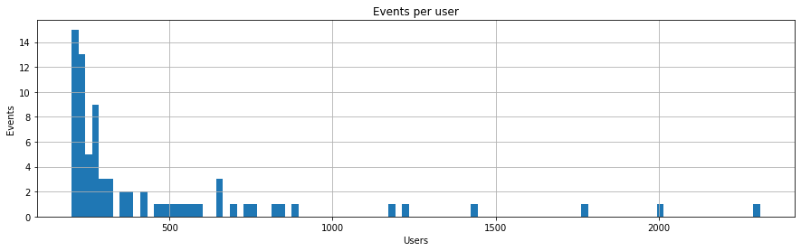

```python
# creating a histogram of events per user
plt.figure(figsize=(15,4))
plt.hist(events_per_user, bins=100, range=(200,2310))
plt.xlabel('Users')
plt.grid()
plt.ylabel('Events')
plt.title('Events per user');
```

```python
# calculating median events per user
median_events_per_user = logs.groupby('user_id').agg({'event_name': 'count'}).median()
print('The median number of events per user: {}'.format(int(median_events_per_user)))
```

```
The median number of events per user: 20
```

### What period do you have data for?

```python
# determining the minimum date
min_date = logs['date_time'].min()

# determining the maximum date
max_date = logs['date_time'].max()

# determining the period
time_delta = max_date - min_date

print('Minimum date: {}'.format(min_date))
print('Maximum date: {}'.format(max_date))
print('Period: {}'.format(time_delta))
```

```
Minimum date: 2019-07-25 04:43:36
Maximum date: 2019-08-07 21:15:17
Period: 13 days 16:31:41
```

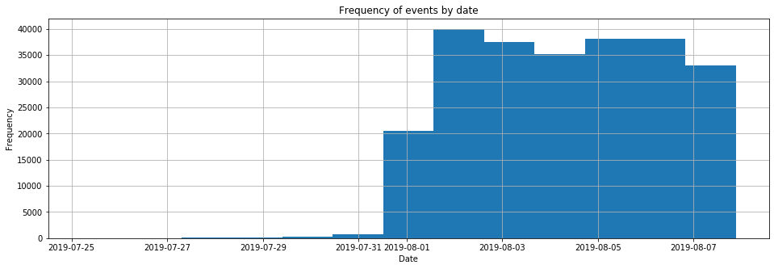

```python
# creating a histogram based on the date and time
plt.figure(figsize=(16, 5))
plt.hist(logs['date_time'], bins = 13)
plt.title('Frequency of events by date')
plt.ylabel('Frequency')
plt.xlabel('Date')
plt.grid()
plt.show()
```

```python
# displaying frequency of events by date
logs.groupby('date').agg({'date_time': 'count'})
```

| date | date_time |
| --- | --- |
| 2019-07-25 | 9 |
| 2019-07-26 | 31 |
| 2019-07-27 | 55 |
| 2019-07-28 | 105 |
| 2019-07-29 | 184 |
| 2019-07-30 | 412 |
| 2019-07-31 | 2030 |
| 2019-08-01 | 36141 |
| 2019-08-02 | 35554 |
| 2019-08-03 | 33282 |
| 2019-08-04 | 32968 |
| 2019-08-05 | 36058 |
| 2019-08-06 | 35788 |
| 2019-08-07 | 31096 |

The histogram and table indicate that the data are complete for the period from 2019-08-01 to 2019-08-07. Let's discard other dates.

```python
# saving data for the period from 2019-08-01 to 2019-08-07 in the logs2 DataFrame
logs2 = logs[logs['date'] >= '2019-08-01']

# displaying on screen
logs2.head()
```

|  | event_name | user_id | timestamp | exp_id | date_time | date |
| --- | --- | --- | --- | --- | --- | --- |
| 2828 | Tutorial | 3737462046622621720 | 1564618048 | 246 | 2019-08-01 00:07:28 | 2019-08-01 |
| 2829 | MainScreenAppear | 3737462046622621720 | 1564618080 | 246 | 2019-08-01 00:08:00 | 2019-08-01 |
| 2830 | MainScreenAppear | 3737462046622621720 | 1564618135 | 246 | 2019-08-01 00:08:55 | 2019-08-01 |
| 2831 | OffersScreenAppear | 3737462046622621720 | 1564618138 | 246 | 2019-08-01 00:08:58 | 2019-08-01 |
| 2832 | MainScreenAppear | 1433840883824088890 | 1564618139 | 247 | 2019-08-01 00:08:59 | 2019-08-01 |

### How many events and users have you lost as a result of discarding data?

```python
# counting events (events_after) and event types (events_type_after) after discarding data
# events and event types before discarding data are in the events and events_type variables
events_after = logs2['event_name'].count()
events_type_after = logs2['event_name'].nunique()

# calculating and displaying the percentage of data that has been deleted
print('Before discarding data, there were {} events and {} types of events.'.format(events, events_type))
print('After discarding data, there were {} events and {} types of events.'.format(events_after, events_type_after))
print('The percentage of deleted data is {:.2%}.'.format(events_after / events - 1))
```

```
Before discarding data, there were 243713 events and 5 types of events.
After discarding data, there were 240887 events and 5 types of events.
The percentage of deleted data is -1.16%.
```

```python
# counting users (users_after) after discarding data
# users before discarding data are in the users variable
users_after = logs2['user_id'].nunique()

# calculating and displaying the percentage of data that has been deleted
print('Before discarding data, there were {} users.'.format(users))
print('After discarding data, there were {} users.'.format(users_after))
print('The percentage of deleted data is {:.2%}.'.format(users_after / users - 1))
```

```
Before discarding data, there were 7551 users.
After discarding data, there were 7534 users.
The percentage of deleted data is -0.23%.
```

- By discarding data, we lost 1.16% of events.
- By discarding data, we lost 0.23% of users.
- Less than 10% of the data can be removed without distorting the analysis.

### Checking that there are users from all three experimental groups

```python
# counting number of users in each of the three experimental groups
logs2.groupby('exp_id').agg({'user_id': 'nunique'})
```

| exp_id | user_id |
| --- | --- |
| 246 | 2484 |
| 247 | 2513 |
| 248 | 2537 |

- We have users from all three experimental groups

**Conclusion**

- There are 243713 events and 5 types of events;
- There are 7551 users;
- The median number of events per user is 20;
- Data can be considered complete for the period from 2019-08-01 to 2019-08-07;
- By discarding incomplete data, we lost 1.16% of events and 0.23% of users;
- We have users from all three experimental groups.

## Funnel of sales

- Check events in the logs and count how often they occur;
- Check how many users made each of these events and calculate the proportion of users who have made an event at least once;
- The order in which events occur;
- Calculating what proportion of users progressed to the next step using the funnel of sales;
- Which step of the process results in the most user loss?
- What proportion of users made it from the first event to payment?

### Checking events in the logs and counting how often they occur

```python
# checking events in the log2 and counting them
logs2.groupby('event_name').agg({'user_id': 'count'}).sort_values(by='user_id', ascending = False)
```

| event_name | user_id |
| --- | --- |
| MainScreenAppear | 117328 |
| OffersScreenAppear | 46333 |
| CartScreenAppear | 42303 |
| PaymentScreenSuccessful | 33918 |
| Tutorial | 1005 |

- Most frequent event is MainScreenAppear.

### Checking how many users made each of these events and calculating the proportion of users who have made an event at least once

```python
# counting users in each event and the proportion of users who who have made an event at least once
# sorting events by users
event_user_count = logs2.groupby('event_name').agg({'user_id': 'nunique'}).sort_values(by='user_id', ascending = False)
event_user_count['percent'] = event_user_count['user_id'] / logs2['user_id'].nunique()
event_user_count.style.format({'percent': '{:,.2%}'})
```

| event_name | user_id | percent |
| --- | --- | --- |
| MainScreenAppear | 7419 | 98.47% |
| OffersScreenAppear | 4593 | 60.96% |
| CartScreenAppear | 3734 | 49.56% |
| PaymentScreenSuccessful | 3539 | 46.97% |
| Tutorial | 840 | 11.15% |

- MainScreenAppear was the most common event for users.

### The order in which events occur

Order of events:

- MainScreenAppear
- OffersScreenAppear
- CartScreenAppear
- PaymentScreenSuccessful
- Tutorial

Tutorial is used rarely and the real order of events looks like this:

- MainScreenAppear
- OffersScreenAppear
- CartScreenAppear
- PaymentScreenSuccessful

### Calculating what proportion of users progressed to the next step using the funnel of sales

For a sequence of events A → B → C, calculate the ratio of users with event B to users with event A, as well as the ratio of users with event C to users with event B.

```python
# removing the Tutorial row
event_user_count = event_user_count[:4]
event_user_count
```

| event_name | user_id | percent |
| --- | --- | --- |
| MainScreenAppear | 7419 | 0.98 |
| OffersScreenAppear | 4593 | 0.61 |
| CartScreenAppear | 3734 | 0.50 |
| PaymentScreenSuccessful | 3539 | 0.47 |

```python
# creating a funnel of sales
fig = go.Figure(layout=go.Layout(title="Funnel of sales"))

fig.add_trace(go.Funnel(
    name = 'Event',
    y = event_user_count.index,
    x = event_user_count['user_id'],
    textinfo = "value+percent previous"))


fig.show()
```

[interactive chart not shown]

- For a sequence of events MainScreenAppear → OffersScreenAppear, 62% progressed to the next step of the funnel.
- For a sequence of events OffersScreenAppear → CartScreenAppear, 81% progressed to the next step of the funnel.
- For a sequence of events CartScreenAppear → PaymentScreenSuccessful, 95% progressed to the next step of the funnel.

### Which step of the process results in the most user loss?

MainScreenAppear to OffersScreenAppear results in the most user loss.

### What proportion of users made it from the first event to payment?

```python
# calculating proportion of users who made it from the first event to payment
event_user_count_copy = event_user_count.copy()
total_uid = event_user_count_copy[event_user_count_copy.index == 'MainScreenAppear']['user_id'][0]
event_user_count_copy['percent'] = event_user_count_copy['user_id'] / total_uid
event_user_count_copy.style.format({'percent': '{:,.2%}'.format})
```

| event_name | user_id | percent |
| --- | --- | --- |
| MainScreenAppear | 7419 | 100.00% |
| OffersScreenAppear | 4593 | 61.91% |
| CartScreenAppear | 3734 | 50.33% |
| PaymentScreenSuccessful | 3539 | 47.70% |

- 47.70% of users made it from the first event to payment.

**Conclusion**

- The most frequent event was MainScreenAppear;
- MainScreenAppear was the most common event for users;
- Events occur in the following order: MainScreenAppear > OffersScreenAppear > CartScreenAppear > PaymentScreenSuccessful;
- Proportion of users progressed to the next step:
  - For a sequence of events MainScreenAppear → OffersScreenAppear, 62% progressed to the next step of the funnel;
  - For a sequence of events OffersScreenAppear → CartScreenAppear, 81% progressed to the next step of the funnel;
  - For a sequence of events CartScreenAppear → PaymentScreenSuccessful, 95% progressed to the next step of the funnel.
- MainScreenAppear to OffersScreenAppear results in the most user loss;
- 47.70% of users made it from the first event to payment.

## Exploring the results of an A/A/B experiment

- How many users are in each experimental group?
- A/A experiment has two control groups to check the accuracy of all mechanisms and calculations. Check if samples 246 and 247 differ in statistical tests.
- A/B experiment has one experimental group to check the accuracy of all mechanisms and calculations. Check if samples 246 and 247 differ with sample 248 in statistical tests.

### How many users are in each experimental group?

```python
# counting users in each experimental group
logs2.groupby('exp_id').agg({'user_id': 'nunique'}).sort_values(by = 'user_id', ascending = False)
```

| exp_id | user_id |
| --- | --- |
| 248 | 2537 |
| 247 | 2513 |
| 246 | 2484 |

- Most users are in the group 248, then 247 and 246.

Let's make sure we don't have users who are members of two or more groups.

```python
# counting how many unique group values each user will have
unique_groups = logs2.groupby('user_id').agg({'exp_id': 'nunique'})

# checking for users who are members of more than 1 group
unique_groups[unique_groups['exp_id'] >= 2].count()
```

```
exp_id    0
dtype: int64
```

- We do not have users who are members of two or more groups.

```python
# looking at the most popular event
logs2.groupby('event_name').agg({'user_id': 'count'}).sort_values(by = 'user_id', ascending = False)
```

| event_name | user_id |
| --- | --- |
| MainScreenAppear | 117328 |
| OffersScreenAppear | 46333 |
| CartScreenAppear | 42303 |
| PaymentScreenSuccessful | 33918 |
| Tutorial | 1005 |

- The most popular event is MainScreenAppear

```python
# counting unique users in the MainScreenAppear event for each group
by_group = logs2[logs2['event_name'] == 'MainScreenAppear'].groupby('exp_id').agg({'user_id': 'nunique'}).sort_values(
    by = 'user_id', ascending = False)
by_group
```

| exp_id | user_id |
| --- | --- |
| 248 | 2493 |
| 247 | 2476 |
| 246 | 2450 |

- Most users of the MainScreenAppear event is in the group 248, then 247 and 246.

```python
# calculating the percentage of users who participated in this event
by_group['percent'] = by_group['user_id'] / logs2['user_id'].nunique() * 100
by_group
```

| exp_id | user_id | percent |
| --- | --- | --- |
| 248 | 2493 | 33.09 |
| 247 | 2476 | 32.86 |
| 246 | 2450 | 32.52 |

- The share of users who participated in the MainScreenAppear event in group 248 is 33.09%, in group 247 - 32.86% and in group 246 - 32.52%.

### A/A experiment has two control groups to check the accuracy of all mechanisms and calculations. Checking if samples 246 and 247 differ in statistical tests.

```python
# saving each experimental group in a separate table
exp_246 = logs2[logs2['exp_id'] == 246]
exp_247 = logs2[logs2['exp_id'] == 247]
exp_248 = logs2[logs2['exp_id'] == 248]

# getting a list with event names
event_name = logs2['event_name'].unique()
```

```python
# creating a function where we calculate 'successes' to test the hypothesis
def all_success(group1, group2, **kwargs):

    successes = [group1[group1[kwargs['column1']] == kwargs['event']][kwargs['column2']].nunique(),
                 group2[group2[kwargs['column1']] == kwargs['event']][kwargs['column2']].nunique()]

    return successes
```

```python
# creating a function where we calculate 'trials' to test the hypothesis
def all_trials(group1, group2, **kwargs):
    trials = np.array([group1[kwargs['column2']].nunique(),
                       group2[kwargs['column2']].nunique()])

    return trials
```

Check if samples 246 and 247 differ in statistical tests.

Let's formulate the null and alternative hypotheses:

- H0: the proportion of unique visitors who visited the funnel stage do not have statistically significant differences;
- H1: the proportion of unique visitors who visited the funnel stage have statistically significant differences.

Let's apply the Bonferroni correction to reduce the probability of type I error.

The error probability in our case without the Bonferroni correction, i.e. with ɑ=0,05: 1-(1-0.05)^12= 46%

The error probability in our case with the Bonferroni correction, i.e. with ɑ=0,004: 1-(1-0.004)^12= 5%

```python
# creating a function to test the hypotheses
def testing_hypothesis(successes, trials, alpha):

    bonferroni_alpha = alpha / 12

    # proportion of successes in the first group:
    p1 = successes[0]/trials[0]

    # proportion of successes in the second group:
    p2 = successes[1]/trials[1]

    # proportion of successes in the combined dataset:
    p_combined = (successes[0] + successes[1]) / (trials[0] + trials[1])

    # difference in proportions
    difference = p1 - p2

    # z-value
    z_value = difference / mth.sqrt(p_combined * (1 - p_combined) * (1/trials[0] + 1/trials[1]))

    # standard normal distribution (mean 0, standard deviation 1)
    distr = st.norm(0, 1)

    # p-value
    p_value = (1 - distr.cdf(abs(z_value))) * 2

    print('p-value: ', p_value)

    if p_value < bonferroni_alpha:
        print('Rejecting the null hypothesis: the proportion of unique visitors who visited the funnel stage have statistically significant differences.')
    else:
        print('Failed to reject the null hypothesis, the proportion of unique visitors who visited the funnel stage do not have statistically significant differences.')
```

```python
# checking if the difference between groups 246 and 247 has statistically significant differences
for event in event_name[1:]:
    successes = all_success(exp_246, exp_247, column1 = 'event_name', column2 = 'user_id', event = event)
    trials = all_trials(exp_246, exp_247, column1 = 'event_name', column2 = 'user_id')
    print('{}'.format(event))
    testing_hypothesis(successes, trials, .05)
    print()
```

```
MainScreenAppear
p-value:  0.7570597232046099
Failed to reject the null hypothesis, the proportion of unique visitors who visited the funnel stage do not have statistically significant differences.

OffersScreenAppear
p-value:  0.2480954578522181
Failed to reject the null hypothesis, the proportion of unique visitors who visited the funnel stage do not have statistically significant differences.

CartScreenAppear
p-value:  0.22883372237997213
Failed to reject the null hypothesis, the proportion of unique visitors who visited the funnel stage do not have statistically significant differences.

PaymentScreenSuccessful
p-value:  0.11456679313141849
Failed to reject the null hypothesis, the proportion of unique visitors who visited the funnel stage do not have statistically significant differences.
```

- At a given critical level of statistical significance, the proportion of unique visitors who visited the funnel stage do not have statistically significant differences;
- The groups were correctly split because there was no statistical significance.

### A/B experiment has one experimental group to check the accuracy of all mechanisms and calculations. Checking if samples 246 and 247 differ with sample 248 in statistical tests.

**Let's compare each of the control groups separately with the experimental group**

```python
# checking if the difference between groups 246 and 248 has statistically significant differences
for event in event_name[1:]:
    successes = all_success(exp_246, exp_248, column1 = 'event_name', column2 = 'user_id', event = event)
    trials = all_trials(exp_246, exp_248, column1 = 'event_name', column2 = 'user_id')
    print('{}'.format(event))
    testing_hypothesis(successes, trials, .05)
    print()
```

```
MainScreenAppear
p-value:  0.2949721933554552
Failed to reject the null hypothesis, the proportion of unique visitors who visited the funnel stage do not have statistically significant differences.

OffersScreenAppear
p-value:  0.20836205402738917
Failed to reject the null hypothesis, the proportion of unique visitors who visited the funnel stage do not have statistically significant differences.

CartScreenAppear
p-value:  0.07842923237520116
Failed to reject the null hypothesis, the proportion of unique visitors who visited the funnel stage do not have statistically significant differences.

PaymentScreenSuccessful
p-value:  0.2122553275697796
Failed to reject the null hypothesis, the proportion of unique visitors who visited the funnel stage do not have statistically significant differences.
```

- At a given critical level of statistical significance, the proportion of unique visitors who visited the funnel stage do not have statistically significant differences.

```python
# checking if the difference between groups 247 and 248 has statistically significant differences
for event in event_name[1:]:
    successes = all_success(exp_247, exp_248, column1 = 'event_name', column2 = 'user_id', event = event)
    trials = all_trials(exp_247, exp_248, column1 = 'event_name', column2 = 'user_id')
    print('{}'.format(event))
    testing_hypothesis(successes, trials, .05)
    print()
```

```
MainScreenAppear
p-value:  0.4587053616621515
Failed to reject the null hypothesis, the proportion of unique visitors who visited the funnel stage do not have statistically significant differences.

OffersScreenAppear
p-value:  0.9197817830592261
Failed to reject the null hypothesis, the proportion of unique visitors who visited the funnel stage do not have statistically significant differences.

CartScreenAppear
p-value:  0.5786197879539783
Failed to reject the null hypothesis, the proportion of unique visitors who visited the funnel stage do not have statistically significant differences.

PaymentScreenSuccessful
p-value:  0.7373415053803964
Failed to reject the null hypothesis, the proportion of unique visitors who visited the funnel stage do not have statistically significant differences.
```

- At a given critical level of statistical significance, the proportion of unique visitors who visited the funnel stage do not have statistically significant differences.

**Let's compare combined control groups with the experimental group**

```python
# combining groups 246 and 247
exp_246_247 = pd.concat([exp_246, exp_247])
```

```python
# checking if the difference between combined groups 246 and 247 and group 248 has statistically significant differences
for event in event_name[1:]:
    successes = all_success(exp_246_247, exp_248, column1 = 'event_name', column2 = 'user_id', event = event)
    trials = all_trials(exp_246_247, exp_248, column1 = 'event_name', column2 = 'user_id')
    print('{}'.format(event))
    testing_hypothesis(successes, trials, .05)
    print()
```

```
MainScreenAppear
p-value:  0.29424526837179577
Failed to reject the null hypothesis, the proportion of unique visitors who visited the funnel stage do not have statistically significant differences.

OffersScreenAppear
p-value:  0.43425549655188256
Failed to reject the null hypothesis, the proportion of unique visitors who visited the funnel stage do not have statistically significant differences.

CartScreenAppear
p-value:  0.18175875284404386
Failed to reject the null hypothesis, the proportion of unique visitors who visited the funnel stage do not have statistically significant differences.

PaymentScreenSuccessful
p-value:  0.6004294282308704
Failed to reject the null hypothesis, the proportion of unique visitors who visited the funnel stage do not have statistically significant differences.
```

- At a given critical level of statistical significance, the proportion of unique visitors who visited the funnel stage do not have statistically significant differences;
- Changing the fonts did not affect the behavior of users.

**Conclusion**

Formulated the null and alternative hypotheses:

- H0: the proportion of unique visitors who visited the funnel stage do not have statistically significant differences;
- H1: the proportion of unique visitors who visited the funnel stage have statistically significant differences.

In A/A experiment tested two control groups 246 and 247:

- At a given critical level of statistical significance, the proportion of unique visitors who visited the funnel stage do not have statistically significant differences;
- The groups were correctly split because there was no statistical significance.

In A/B experiment tested two control groups 246 and 247 with experimental group 248:

- At a given critical level of statistical significance, the proportion of unique visitors who visited the funnel stage do not have statistically significant differences;
- Changing the fonts did not affect the behavior of users. That is, changing the fonts will not affect sales.

## Final conclusion

**After examining data:**

- There are 243713 events and 5 types of events;
- There are 7551 users;
- The median number of events per user is 20;
- Data can be considered complete for the period from 2019-08-01 to 2019-08-07;
- By discarding incomplete data, we lost 1.16% of events and 0.23% of users;
- We have users from all three experimental groups.

**After exploring the funnel of sales:**

- The most frequent event was MainScreenAppear;
- MainScreenAppear was the most common event for users;
- Events occur in the following order: MainScreenAppear > OffersScreenAppear > CartScreenAppear > PaymentScreenSuccessful;
- Proportion of users progressed to the next step:
  - For a sequence of events MainScreenAppear → OffersScreenAppear, 62% progressed to the next step of the funnel;
  - For a sequence of events OffersScreenAppear → CartScreenAppear, 81% progressed to the next step of the funnel;
  - For a sequence of events CartScreenAppear → PaymentScreenSuccessful, 95% progressed to the next step of the funnel.
- MainScreenAppear to OffersScreenAppear results in the most user loss;
- 47.70% of users made it from the first event to payment.

**After exploring the results of an A/A/B experiment:**

Formulated the null and alternative hypotheses:

- H0: the proportion of unique visitors who visited the funnel stage do not have statistically significant differences;
- H1: the proportion of unique visitors who visited the funnel stage have statistically significant differences.

In A/A experiment tested two control groups 246 and 247:

- At a given critical level of statistical significance, the proportion of unique visitors who visited the funnel stage do not have statistically significant differences;
- The groups were correctly split because there was no statistical significance.

In A/B experiment tested two control groups 246 and 247 with experimental group 248:

- At a given critical level of statistical significance, the proportion of unique visitors who visited the funnel stage do not have statistically significant differences;
- Changing the fonts did not affect the behavior of users. That is, changing the fonts will not affect sales.